Part 0. - Opening Remarks and Thoughts  
Part 1. - SQL  
.........Data Viz 1 - Articles Posted By Day of Week  
Part 2. - Python  
.........Data Viz 2 - "Investigating Modern-Day Slavery in the South" Cumulative Impressions  
.........Data Viz 3 - Engament Metrics  
.........Data Viz 4 - Total Impressions by Veritcal

# Part 0. - Opening Remarks and Thoughts

### Overall here’s the gameplan I used for this analysis:

**SQL**  
For the SQL portion, I loaded the CSV into a MySQL local database, and I ran my queries in MySQL Workbench. To conveniently display the results, I used Python to connect to the local database and display the tables as Pandas dataframes. When I thought it was especially cool, I visualized the data. Where applicable, I ran separate queries to show more than one way of getting to a given insight.

**Python**  
For the Python portion, I first used some looping to get the filepaths for all the JSON files. Since all the JSON files were line delimited, I could use another loop to load all the JSON lines into a data structure, and then flatten the data structure using Python's JSON module’s normalize method. This got everything into a Pandas dataframe with about 3000 rows and over 500 columns. These hundreds of columns were necessary because we had to unpack all the nested cells. I used another loop to read through the columns, and selected which columns held information relevant to the questions asked. Then, I used SQLite to—within the script—take the entire Pandas dataframe and convert it into a database. Since it would be too messy to load all the columns into a database program, I just kept the entire structure within the script. Then I could internally query the data via Python, and you can see the way I got answers.  
One of the most interesting mathematical situations was the cumulative nature of the data. So daily rates all depend on a max() – min() difference for a given time period. Moving forward, in a more stable ETL pipeline, I’d recommend we run a function to save daily incremental changes into a table, which will be easier for others to query.

**A Few Data Visualizations...**  
To break up all this text and code, I wanted to show a few visualizations I thought were interesting. They are by no means exhaustive.

Here is a SQL histogram visualization. It is cool to see how articles post per day of the week. It’s clear that on the weekends there are a lot fewer articles. At the same time, it’s possible that more people are on social media on the weekends, so we may want to see if we can increase the number of posts on the weekends, and see if that drives engagement. We can set up a statistical experiment to test this, by the way.

[figure not shown]

If we look at daily engagement, we can actually see the impact of a mega article. Here you can see what the "Investigating Modern-Day Slavery in the South" article/video did to daily shares/impressions. As a benchmark comparison, in my experience, a friend's post on your own personal Facebook timeline is not going to get an 8% shares-to-impressions ratio, so this is very good. Further, regarding the splash on March 4th in shares-per-impresion: my hunch is that people shared this post but didn't necessarily 'like' it, and that makes sense because it's something you'd want other people to know about it, but not for a happy, 'likable' reason.

[figure not shown]

As alluded to above, the top post in the data set "Investigating Modern-Day Slavery in the South." This graph depicts the posts incredible reach. This is something I would like to dig deeper in in future analyses.

[figure not shown]

[figure not shown]

*And now the code…*

```python
import os
import json
import pandas as pd
import numpy as np
from pandas.io.json import json_normalize
from matplotlib import pyplot as plt
import sqlite3 as sql
import mysql.connector as mysql
```

# Part 1. - SQL

### 1. Each unique article is represented by a six charater, alphanumeric ID in the URL string. Start this exercise by using a regular expression to extract the article_id from the URL.

### For example, xwpd7w is the article_id here https://www.vice.com/en_us/article/xwpd7w/how-a-brooklyn-gang-may-have-gotten-crazy-rich-dealing-for-el-chapo

```python
#connecting to the local sql database I set up
db = mysql.connect(
    host = "localhost",
    user = "newuser",
    passwd = "data",
    auth_plugin='mysql_native_password',
    database = 'sys')
```

```python
article_id_strings = pd.read_sql("""
SELECT
     REGEXP_SUBSTR(url, '......', locate('article/', url)+ length('article/')) as article_id
FROM sys.vice
""", con=db)
```

```python
article_id_strings.head(10)
```

|  | article_id |
| --- | --- |
| 0 | j539yy |
| 1 | qv9wn5 |
| 2 | wjy8en |
| 3 | gyeaqb |
| 4 | gyea53 |
| 5 | a3p8mg |
| 6 | 594nwq |
| 7 | 598xaa |
| 8 | wjyzgx |
| 9 | j5393d |

### 2. Using the published_day field, calculate the unique daily and weekly article output. How does the content output trend throughout the week?

I'm answering this questions in 4 parts:  
A) - Unique daily article output (which I assume is the count of the articles per day)  
B) - Unique weekly article output (which I assume is the count of the articles per week)  
C) - A count of artils per day, in a list format (so not an average)  
D) - A list and a data viz of which day per week gets how many counts of articles over the duration

```python
#A)
unique_daily_output = pd.read_sql("""
SELECT
count( distinct date(published_day)) as days, #there are 62 days,
count( distinct url) as articles, #there are about 20k articles
round(count( distinct url) / count( distinct date(published_day)),2) as daily_rate
FROM sys.vice;
""", con=db)
```

```python
unique_daily_output
```

|  | days | articles | daily_rate |
| --- | --- | --- | --- |
| 0 | 62 | 20068 | 323.68 |

```python
#B)
unique_weekly_output = pd.read_sql("""
SELECT
count( distinct extract(week from published_day)) as weeks, #there are 10 weeks,
count( distinct url) as articles, #there are about 20k articles
round(count( distinct url) / count( distinct extract(week from published_day)),2) as weekly_rate
FROM sys.vice;
""", con=db)
```

```python
unique_weekly_output
```

|  | weeks | articles | weekly_rate |
| --- | --- | --- | --- |
| 0 | 10 | 20068 | 2006.8 |

```python
#C)
articles_per_day_list = pd.read_sql("""
SELECT
date(published_day) as date,
count(distinct url) as articles
FROM sys.vice
group by 1
order by 1 asc;
""", con=db)
```

```python
articles_per_day_list.head()
```

|  | date | articles |
| --- | --- | --- |
| 0 | 2018-09-01 | 60 |
| 1 | 2018-09-02 | 59 |
| 2 | 2018-09-03 | 289 |
| 3 | 2018-09-04 | 438 |
| 4 | 2018-09-05 | 415 |

```python
#D)
articles_by_day_of_week = pd.read_sql("""
SELECT
dayofweek(published_day) as 'day_of_week', #btw 1 = Sunday
count(distinct url) as articles
FROM sys.vice
group by 1
order by 2 asc;
""", con=db)
```

```python
articles_by_day_of_week
#1 = Sunday
```

|  | day_of_week | articles |
| --- | --- | --- |
| 0 | 1 | 650 |
| 1 | 7 | 653 |
| 2 | 6 | 3271 |
| 3 | 2 | 3529 |
| 4 | 5 | 3931 |
| 5 | 3 | 3984 |
| 6 | 4 | 4050 |

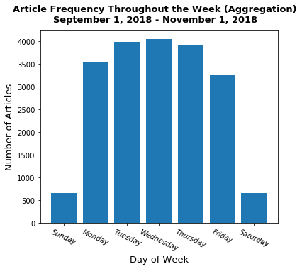

```python
f, ax = plt.subplots(figsize=(6, 5))
plt.bar(articles_by_day_of_week.day_of_week,articles_by_day_of_week.articles)
plt.xlabel("Day of Week", fontsize = 13)
plt.locator_params(axis='x', nbins=12)
ax.set_xticklabels(['0','Sunday','Monday', 'Tuesday', 'Wednesday','Thursday', 'Friday',\
                   'Saturday'], style='italic')
plt.xticks(rotation=-25)
plt.ylabel("Number of Articles", fontsize = 13)
plt.suptitle("Article Frequency Throughout the Week (Aggregation)\nSeptember 1, 2018 - November 1, 2018",\
            fontsize = 13, fontweight = 'bold')
plt.savefig("ex_1_day_of_week.png", bbox_inches = "tight")
plt.show()
```

### 3. VICE's editorial department is structured into different verticals (e.g. Noisey covers music and Motherboard covers tech).

### How does each vertical contribute to the editorial output? Write a query creating a table showing each vertical, its unique content output, and that vertical's share of the total output over the full data period.

```python
#this is a little trickier because there are two sql statements to be run sequentially
#we split them up in the following way

sql1="set @total_article_count = (select count(distinct url) from sys.vice);"
sql2="""
select
vertical as veritcal,
count( distinct url) as article_count,
round(100.0*(count( distinct url) / @total_article_count),2) as prct_of_whole
from sys.vice
group by 1
order by 3 desc;
"""
cursor=db.cursor(buffered=True)
cursor.execute(sql1)
cursor.close()

vertical_contributions = pd.read_sql(sql2, con=db)
```

```python
vertical_contributions.head()
```

|  | veritcal | article_count | prct_of_whole |
| --- | --- | --- | --- |
| 0 | VICE | 9597 | 47.82 |
| 1 | i-D | 2288 | 11.40 |
| 2 | Noisey | 2251 | 11.22 |
| 3 | Motherboard | 1337 | 6.66 |
| 4 | Munchies | 1169 | 5.83 |

### 4. VICE publishes content across a range of global offices. Each unique office is identified by their locale which is represented using a locale url parameter (e.g. en_us for the United States and en_uk for the United Kingdom). However, not every vertical publishes content in every locale.

### Which verticals are published in which locales? Write a query creating a table showing each locale, their total article output, and a concatenated list of all of the verticals publishing in each locale.

```python
locale_verticals_lists_and_counts = pd.read_sql("""
SELECT
locale,
count(distinct url) as article_count,
group_concat(distinct vertical order by vertical asc) as list_locale_verticals,
count(distinct vertical) as count_locale_verticals
FROM sys.vice
group by 1
order by 2 desc
;
""", con=db)
```

```python
#verticals are concatenated alphabetically
locale_verticals_lists_and_counts.head()
```

|  | locale | article_count | list_locale_verticals | count_locale_verticals |
| --- | --- | --- | --- | --- |
| 0 | en_us | 4225 | Amuse,Broadly,FREE,Garage,i-D,Motherboard,Munc... | 13 |
| 1 | en_uk | 1564 | Broadly,FREE,i-D,Motherboard,Munchies,Noisey,T... | 8 |
| 2 | en_au | 1465 | Broadly,Creators,FREE,i-D,Motherboard,Munchies... | 9 |
| 3 | en_ca | 1418 | FREE,Noisey,VICE,VICE News,VICE Sports | 5 |
| 4 | es_latam | 1119 | Amuse,Broadly,Motherboard,Munchies,Noisey,Toni... | 7 |

# Part 2. - Python

### 1. Please read in all of the files into a single data structure that will be usable for further analysis (for example, a pandas DataFrame)

```python
#first we need to get a list that literally has all the file names
parent_path = 'Facebook Data'
list_of_files = []
for folder in os.listdir(parent_path):
    if folder != ".DS_Store": #just need to skip over this one since it's not a proper directory
        for json_file in os.listdir(os.path.join(parent_path, folder)):
            list_of_files.append(os.path.join(parent_path, folder, json_file))
```

```python
#example
list_of_files[:5]
```

```
['Facebook Data/2018-03-07/.DS_Store',
 'Facebook Data/2018-03-07/2018-03-07_VICE_asof_2018-03-09-000.json',
 'Facebook Data/2018-03-07/2018-03-07_VICE_asof_2018-03-08-000.json',
 'Facebook Data/2018-03-07/2018-03-07_VICE-Video_asof_2018-03-08-000.json',
 'Facebook Data/2018-03-07/2018-03-07_VICE-Video_asof_2018-03-09-000.json']
```

```python
#next we have to go through that list of files, and make sure we only have the JSONs
all_the_presidents_jsons = [x for x in list_of_files if x.endswith('.json')]
```

```python
#example
#no more .DS_Store, etc.
all_the_presidents_jsons[:5]
```

```
['Facebook Data/2018-03-07/2018-03-07_VICE_asof_2018-03-09-000.json',
 'Facebook Data/2018-03-07/2018-03-07_VICE_asof_2018-03-08-000.json',
 'Facebook Data/2018-03-07/2018-03-07_VICE-Video_asof_2018-03-08-000.json',
 'Facebook Data/2018-03-07/2018-03-07_VICE-Video_asof_2018-03-09-000.json',
 'Facebook Data/2018-03-07/2018-03-07_MOTHERBOARD_asof_2018-03-08-000.json']
```

```python
#we can see there were a lot of JSONs (155 files)
len(all_the_presidents_jsons)
```

```
155
```

```python
#now we need to take each line from the JSON (they are line delimited), and combine them into one place
data = []
for i in all_the_presidents_jsons:
    with open(i) as f:
        for line in f:
            data.append(json.loads(line))
```

```python
#then we need to flatten the JSONs since there are tons of nested files, and we need to get it into pandas
vice_data = json_normalize(data)
```

```python
#this is to make sure I can view all the columns
pd.set_option('display.max_columns', None)
#this is to fix the spaces that came into the unnested headers
vice_data.columns = vice_data.columns.str.replace(' ', '_')
vice_data.head(4)
```

|  | asof_date | comments_total_count | created_time | from_id | from_name | id | link | name | post_consumptions | post_consumptions_by_type.link_clicks | post_consumptions_by_type.other_clicks | post_consumptions_by_type.photo_view | post_consumptions_by_type.video_play | post_consumptions_by_type_unique.link_clicks | post_consumptions_by_type_unique.other_clicks | post_consumptions_by_type_unique.photo_view | post_consumptions_by_type_unique.video_play | post_consumptions_unique | post_engaged_fan | post_engaged_users | post_engagements | post_fan_reach | post_impressions | post_impressions_by_paid_non_paid.paid | post_impressions_by_paid_non_paid.total | post_impressions_by_paid_non_paid.unpaid | post_impressions_by_paid_non_paid_unique.paid | post_impressions_by_paid_non_paid_unique.total | post_impressions_by_paid_non_paid_unique.unpaid | … |
| --- | --- | --- | --- | --- | --- | --- | --- | --- | --- | --- | --- | --- | --- | --- | --- | --- | --- | --- | --- | --- | --- | --- | --- | --- | --- | --- | --- | --- | --- | --- |
| 0 | 2018-03-09-000 | 40 | 2018-03-07T23:30:00+0000 | 167115176655082 | VICE | 167115176655082_2094008024166264 | https://www.facebook.com/VICE/videos/209400802... | Being A Trans Women's Hockey Player | 6366 | 355.0 | 5430.0 | 2.0 | 579.0 | 340.0 | 4039.0 | 2.0 | 584.0 | 4469 | 4357 | 4541 | 6583 | 225447 | 278195 | 0 | 278195 | 278195 | 0 | 230021 | 230021 | … |
| 1 | 2018-03-09-000 | 139 | 2018-03-07T23:01:30+0000 | 167115176655082 | VICE | 167115176655082_2061072230592691 | https://motherboard.vice.com/en_us/article/pam... | Google Engineers Think This 72-Qubit Processor... | 31706 | 21592.0 | 10110.0 | 4.0 | NaN | 20440.0 | 7638.0 | 4.0 | NaN | 26855 | 27040 | 28404 | 34358 | 416752 | 581612 | 0 | 581612 | 581612 | 0 | 449338 | 449338 | … |
| 2 | 2018-03-09-000 | 106 | 2018-03-07T22:30:27+0000 | 167115176655082 | VICE | 167115176655082_2061036290596285 | https://noisey.vice.com/en_us/article/9kz7jp/v... | I, Like Vince Staples, Will "Shut the Fuck Up ... | 19233 | 9664.0 | 9568.0 | 1.0 | NaN | 9251.0 | 7528.0 | 1.0 | NaN | 15031 | 15083 | 16008 | 21563 | 274787 | 380562 | 0 | 380562 | 380562 | 0 | 291179 | 291179 | … |
| 3 | 2018-03-09-000 | 54 | 2018-03-07T22:01:21+0000 | 167115176655082 | VICE | 167115176655082_2061006690599245 | https://www.vice.com/en_us/article/qve9yq/my-t... | Here Are Some Solid Options for Trump's Next W... | 3244 | 1771.0 | 1472.0 | 1.0 | NaN | 1673.0 | 1133.0 | 1.0 | NaN | 2681 | 2796 | 2880 | 3678 | 200117 | 267465 | 0 | 267465 | 267465 | 0 | 204979 | 204979 | … |

```python
#We'll want to get an idea of the size of this dataframe
vice_data.shape
```

```
(3001, 553)
```

```python
#We'll also want a reference place to check the columns now and again since there are so many:
#You can scroll through this or text search it to find what you may need.
for i in vice_data.columns:
    print(i)
```

```
asof_date
comments_total_count
created_time
from_id
from_name
id
link
name
post_consumptions
post_consumptions_by_type.link_clicks
post_consumptions_by_type.other_clicks
post_consumptions_by_type.photo_view
post_consumptions_by_type.video_play
post_consumptions_by_type_unique.link_clicks
post_consumptions_by_type_unique.other_clicks
post_consumptions_by_type_unique.photo_view
post_consumptions_by_type_unique.video_play
post_consumptions_unique
post_engaged_fan
post_engaged_users
post_engagements
post_fan_reach
post_impressions
post_impressions_by_paid_non_paid.paid
post_impressions_by_paid_non_paid.total
post_impressions_by_paid_non_paid.unpaid
post_impressions_by_paid_non_paid_unique.paid
post_impressions_by_paid_non_paid_unique.total
post_impressions_by_paid_non_paid_unique.unpaid
post_impressions_by_story_type.other
post_impressions_by_story_type_unique.other
post_impressions_fan
post_impressions_fan_paid
post_impressions_fan_paid_unique
post_impressions_fan_unique
post_impressions_organic
post_impressions_organic_unique
post_impressions_paid
post_impressions_paid_unique
post_impressions_unique
```

[output cut: 498 more lines]

```
post_video_views_10s_paid
post_video_views_10s_sound_on
post_video_views_10s_unique
post_video_views_autoplayed
post_video_views_by_distribution_type.page_owned
post_video_views_by_distribution_type.shared
post_video_views_clicked_to_play
post_video_views_organic
post_video_views_organic_unique
post_video_views_paid
post_video_views_paid_unique
post_video_views_sound_on
post_video_views_unique
shares
shares.count
```

```python
#For our data to be really high-powered, we need to get the dates into datetimes.
#first, can we handle the date time
#'%m/%d/%y'
vice_data['asof_date'] = pd.to_datetime(vice_data['asof_date'],\
                                             format='%Y-%m-%d-000')
vice_data['created_time'] = pd.to_datetime(vice_data['created_time'],\
                                                format='%Y-%m-%dT%H:%M:%S+0000')
```

```python
vice_data.head(3)
```

|  | asof_date | comments_total_count | created_time | from_id | from_name | id | link | name | post_consumptions | post_consumptions_by_type.link_clicks | post_consumptions_by_type.other_clicks | post_consumptions_by_type.photo_view | post_consumptions_by_type.video_play | post_consumptions_by_type_unique.link_clicks | post_consumptions_by_type_unique.other_clicks | post_consumptions_by_type_unique.photo_view | post_consumptions_by_type_unique.video_play | post_consumptions_unique | post_engaged_fan | post_engaged_users | post_engagements | post_fan_reach | post_impressions | post_impressions_by_paid_non_paid.paid | post_impressions_by_paid_non_paid.total | post_impressions_by_paid_non_paid.unpaid | post_impressions_by_paid_non_paid_unique.paid | post_impressions_by_paid_non_paid_unique.total | post_impressions_by_paid_non_paid_unique.unpaid | … |
| --- | --- | --- | --- | --- | --- | --- | --- | --- | --- | --- | --- | --- | --- | --- | --- | --- | --- | --- | --- | --- | --- | --- | --- | --- | --- | --- | --- | --- | --- | --- |
| 0 | 2018-03-09 | 40 | 2018-03-07 23:30:00 | 167115176655082 | VICE | 167115176655082_2094008024166264 | https://www.facebook.com/VICE/videos/209400802... | Being A Trans Women's Hockey Player | 6366 | 355.0 | 5430.0 | 2.0 | 579.0 | 340.0 | 4039.0 | 2.0 | 584.0 | 4469 | 4357 | 4541 | 6583 | 225447 | 278195 | 0 | 278195 | 278195 | 0 | 230021 | 230021 | … |
| 1 | 2018-03-09 | 139 | 2018-03-07 23:01:30 | 167115176655082 | VICE | 167115176655082_2061072230592691 | https://motherboard.vice.com/en_us/article/pam... | Google Engineers Think This 72-Qubit Processor... | 31706 | 21592.0 | 10110.0 | 4.0 | NaN | 20440.0 | 7638.0 | 4.0 | NaN | 26855 | 27040 | 28404 | 34358 | 416752 | 581612 | 0 | 581612 | 581612 | 0 | 449338 | 449338 | … |
| 2 | 2018-03-09 | 106 | 2018-03-07 22:30:27 | 167115176655082 | VICE | 167115176655082_2061036290596285 | https://noisey.vice.com/en_us/article/9kz7jp/v... | I, Like Vince Staples, Will "Shut the Fuck Up ... | 19233 | 9664.0 | 9568.0 | 1.0 | NaN | 9251.0 | 7528.0 | 1.0 | NaN | 15031 | 15083 | 16008 | 21563 | 274787 | 380562 | 0 | 380562 | 380562 | 0 | 291179 | 291179 | … |

# HOORAY! We've got a working Pandas dataframe! One more thing I want to do to it now...

```python
#let's make it query-able so that we can do more complex analysis to the table
#connecting
conn = sql.connect("vice.db") #reading in takehome data assignment
#notice that we used "con" with 1 n for the MySQL database
#and we are using "conn" with 2 n's for the sqlite inline database
#prepaing for SQL
vice_data.to_sql("vice",conn,if_exists='replace',index=False)
```

```python
pd.read_sql_query("""
SELECT
    *
FROM vice
limit 4
""", conn)
```

|  | asof_date | comments_total_count | created_time | from_id | from_name | id | link | name | post_consumptions | post_consumptions_by_type.link_clicks | post_consumptions_by_type.other_clicks | post_consumptions_by_type.photo_view | post_consumptions_by_type.video_play | post_consumptions_by_type_unique.link_clicks | post_consumptions_by_type_unique.other_clicks | post_consumptions_by_type_unique.photo_view | post_consumptions_by_type_unique.video_play | post_consumptions_unique | post_engaged_fan | post_engaged_users | post_engagements | post_fan_reach | post_impressions | post_impressions_by_paid_non_paid.paid | post_impressions_by_paid_non_paid.total | post_impressions_by_paid_non_paid.unpaid | post_impressions_by_paid_non_paid_unique.paid | post_impressions_by_paid_non_paid_unique.total | post_impressions_by_paid_non_paid_unique.unpaid | … |
| --- | --- | --- | --- | --- | --- | --- | --- | --- | --- | --- | --- | --- | --- | --- | --- | --- | --- | --- | --- | --- | --- | --- | --- | --- | --- | --- | --- | --- | --- | --- |
| 0 | 2018-03-09 00:00:00 | 40 | 2018-03-07 23:30:00 | 167115176655082 | VICE | 167115176655082_2094008024166264 | https://www.facebook.com/VICE/videos/209400802... | Being A Trans Women's Hockey Player | 6366 | 355.0 | 5430.0 | 2.0 | 579.0 | 340.0 | 4039.0 | 2.0 | 584.0 | 4469 | 4357 | 4541 | 6583 | 225447 | 278195 | 0 | 278195 | 278195 | 0 | 230021 | 230021 | … |
| 1 | 2018-03-09 00:00:00 | 139 | 2018-03-07 23:01:30 | 167115176655082 | VICE | 167115176655082_2061072230592691 | https://motherboard.vice.com/en_us/article/pam... | Google Engineers Think This 72-Qubit Processor... | 31706 | 21592.0 | 10110.0 | 4.0 | NaN | 20440.0 | 7638.0 | 4.0 | NaN | 26855 | 27040 | 28404 | 34358 | 416752 | 581612 | 0 | 581612 | 581612 | 0 | 449338 | 449338 | … |
| 2 | 2018-03-09 00:00:00 | 106 | 2018-03-07 22:30:27 | 167115176655082 | VICE | 167115176655082_2061036290596285 | https://noisey.vice.com/en_us/article/9kz7jp/v... | I, Like Vince Staples, Will "Shut the Fuck Up ... | 19233 | 9664.0 | 9568.0 | 1.0 | NaN | 9251.0 | 7528.0 | 1.0 | NaN | 15031 | 15083 | 16008 | 21563 | 274787 | 380562 | 0 | 380562 | 380562 | 0 | 291179 | 291179 | … |
| 3 | 2018-03-09 00:00:00 | 54 | 2018-03-07 22:01:21 | 167115176655082 | VICE | 167115176655082_2061006690599245 | https://www.vice.com/en_us/article/qve9yq/my-t... | Here Are Some Solid Options for Trump's Next W... | 3244 | 1771.0 | 1472.0 | 1.0 | NaN | 1673.0 | 1133.0 | 1.0 | NaN | 2681 | 2796 | 2880 | 3678 | 200117 | 267465 | 0 | 267465 | 267465 | 0 | 204979 | 204979 | … |

# 👆🏿Now that's what I'm talking about!! 😊

### 2. Recall that all of the records are "point-in-time" or "stock" data. For many of the below questions, you'll need to use "over time" or "flow" data. Develop a methodology that converts the stock data for a field, for example impressions into flow data to see how many impressions a post received between two timestamps

The key to converting the ‘point-in-time’ data to ‘flow’ data is that we are dealing with cumulative data. This is a calculus-esque area-under-the-curve concept. We can find the flow data by finding the difference between the max and the min given a time window constraint. One cool thing about cumulative numbers is that—at least in this case—they are one-way directional. So they should either stay the same or get better, but we can’t really lose a cumulative impression.

So my methodology is basically to query the Pandas dataframe for a certain time window, for a certain column value, and simply subtract the difference between the max and min value for that period to get the incremental or ‘flow’ data.

As I said in Part 0 above, and as I will say at the end of the assignment, we’d want to institute a practice like this at the ETL state because it will make the tables easier to query and to understand, and a simple SQL aggregation function will get us to the cumulative numbers should we need to see them.

```python
#consider the following for a random story I selected from the data:
pd.read_sql_query("""
SELECT
    id,
    name,
    asof_date,
    created_time,
    post_impressions
FROM vice
WHERE id = '130581413665173_1772390549484243'
ORDER BY asof_date DESC
""", conn)
```

|  | id | name | asof_date | created_time | post_impressions |
| --- | --- | --- | --- | --- | --- |
| 0 | 130581413665173_1772390549484243 | Blunted | 2018-03-08 00:00:00 | 2018-03-01 22:30:00 | 43452 |
| 1 | 130581413665173_1772390549484243 | Blunted | 2018-03-07 00:00:00 | 2018-03-01 22:30:00 | 43359 |
| 2 | 130581413665173_1772390549484243 | Blunted | 2018-03-06 00:00:00 | 2018-03-01 22:30:00 | 43207 |
| 3 | 130581413665173_1772390549484243 | Blunted | 2018-03-05 00:00:00 | 2018-03-01 22:30:00 | 41354 |
| 4 | 130581413665173_1772390549484243 | Blunted | 2018-03-04 00:00:00 | 2018-03-01 22:30:00 | 38076 |
| 5 | 130581413665173_1772390549484243 | Blunted | 2018-03-03 00:00:00 | 2018-03-01 22:30:00 | 33666 |
| 6 | 130581413665173_1772390549484243 | Blunted | 2018-03-02 00:00:00 | 2018-03-01 22:30:00 | 7323 |

```python
#let's say we want to see the impressions it gained from March 4th to March 4th
#we just will limit to those days and do a max - min for the difference
#NOTE: in the BETWEEN SQL function, on the upper bound date by 1 day because all the dates
#are at midnight, and since BETWEEN is an exlusive function, I think it gets confused
pd.read_sql_query("""
SELECT
    id,
    name,
    max(post_impressions) - min(post_impressions) as period_incremental_impressions,
    min(date(asof_date)) as period_start,
    max(date(asof_date)) as period_end
FROM vice
WHERE id = '130581413665173_1772390549484243'
AND asof_date BETWEEN '2018-03-04' AND '2018-03-06' --here is where we set the time period we want to check
GROUP BY 1,2
""", conn)
```

|  | id | name | period_incremental_impressions | period_start | period_end |
| --- | --- | --- | --- | --- | --- |
| 0 | 130581413665173_1772390549484243 | Blunted | 3278 | 2018-03-04 | 2018-03-05 |

```python
#this is just what we wanted...it checks out:
41354 - 38076
```

```
3278
```

### 3. Which post id received the most total impressions?

```python
#which ID got the most impressions
pd.read_sql_query("""
SELECT
    id,
    name,
    date(asof_date) as date,
    created_time,
    post_impressions
FROM vice
ORDER BY post_impressions DESC
LIMIT 1
""", conn)
```

|  | id | name | date | created_time | post_impressions |
| --- | --- | --- | --- | --- | --- |
| 0 | 167115176655082_1773445632712068 | Investigating Modern-Day Slavery in the South | 2018-03-09 | 2018-03-02 20:30:00 | 13090657 |

```python
#by the way we can also look at this post overtime, just out of curiosity:
modern_slavery = pd.read_sql_query("""
SELECT
    id,
    name,
    asof_date,
    created_time,
    post_impressions
FROM vice
WHERE id = '167115176655082_1773445632712068'
ORDER BY asof_date ASC
""", conn)
```

```python
modern_slavery
```

|  | id | name | asof_date | created_time | post_impressions |
| --- | --- | --- | --- | --- | --- |
| 0 | 167115176655082_1773445632712068 | Investigating Modern-Day Slavery in the South | 2018-03-03 00:00:00 | 2018-03-02 20:30:00 | 254108 |
| 1 | 167115176655082_1773445632712068 | Investigating Modern-Day Slavery in the South | 2018-03-04 00:00:00 | 2018-03-02 20:30:00 | 2920010 |
| 2 | 167115176655082_1773445632712068 | Investigating Modern-Day Slavery in the South | 2018-03-05 00:00:00 | 2018-03-02 20:30:00 | 7409355 |
| 3 | 167115176655082_1773445632712068 | Investigating Modern-Day Slavery in the South | 2018-03-06 00:00:00 | 2018-03-02 20:30:00 | 9440545 |
| 4 | 167115176655082_1773445632712068 | Investigating Modern-Day Slavery in the South | 2018-03-07 00:00:00 | 2018-03-02 20:30:00 | 10481088 |
| 5 | 167115176655082_1773445632712068 | Investigating Modern-Day Slavery in the South | 2018-03-08 00:00:00 | 2018-03-02 20:30:00 | 11929361 |
| 6 | 167115176655082_1773445632712068 | Investigating Modern-Day Slavery in the South | 2018-03-09 00:00:00 | 2018-03-02 20:30:00 | 13090657 |

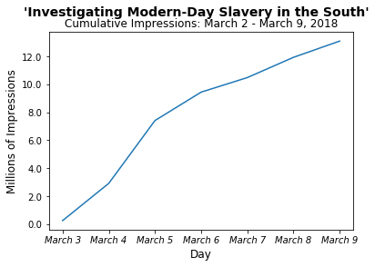

```python
p1 = plt.plot(modern_slavery.asof_date, modern_slavery.post_impressions)
ax_ = plt.subplot()
vals = ax_.get_yticks()
ax_.set_yticklabels(['{:,.1f}'.format(x/1000000) for x in vals])
ax_.set_xticklabels(['March 3','March 4', 'March 5', 'March 6','March 7', 'March 8',\
                   'March 9'], style='italic')
plt.xlabel("Day", fontsize = 12)
plt.ylabel("Millions of Impressions", fontsize = 12)
plt.suptitle("'Investigating Modern-Day Slavery in the South'", fontsize = 14, fontweight='bold')
plt.title("Cumulative Impressions: March 2 - March 9, 2018")
plt.savefig("ex_2_modern_slavery_post_cumulative_impressions.png", bbox_inches = "tight")
plt.show()
```

# 👆🏿This is very impressive, and it speaks to the public's hunger for powerful journalism.

### 4. How many total impressions across all posts were there on 2018-03-06?

```python
cumulative_impressions = pd.read_sql_query("""
SELECT
    date(asof_date) as date,
    sum(post_impressions) as cumulative_impressions
FROM vice
GROUP BY 1
ORDER BY 1 ASC
""", conn)
```

```python
cumulative_impressions
```

|  | date | cumulative_impressions |
| --- | --- | --- |
| 0 | 2018-03-02 | 21046132 |
| 1 | 2018-03-03 | 49947726 |
| 2 | 2018-03-04 | 86610270 |
| 3 | 2018-03-05 | 129327061 |
| 4 | 2018-03-06 | 168393335 |
| 5 | 2018-03-07 | 205730913 |
| 6 | 2018-03-08 | 235716760 |
| 7 | 2018-03-09 | 210838373 |

```python
#impressions across VICE on March 6
print(str(cumulative_impressions.cumulative_impressions[4] - cumulative_impressions.cumulative_impressions[3])\
+ " impressions")
```

```
39066274 impressions
```

**Please Note:** I will want to talk with the team to see if ~40 million impressions in a day is reasonable. At first, I thought it was high, but if we do a rough back-of-the-envelope calculation, it doesn't seem unheard of. We have about 3,000 rows of data across the database-dataframe, which include duplicate articles over 8 days. Let's say we have, on average, 3000/8 = 375 articles a day. Then, if we divide 40 million impressions by 375, we get about 107,000 impressions per article per day on average. Considering that there are some blockbuster articles/videos, I think this isn't unreasonable for an average, but I would certainly flag this and check with the team.

**Assumption:** I assume that the impressions listed for, say, the March 6th entry are all the impressions accumulated by the very end of March 6th. Thus, if I subtract the cumulative March 5th entry from the cumulative March 6th entry, I'll get the incremental March 6th numbers.

**Please Also Note:** Notice that March 9th has fewer cumulative impressions than March 8th does. This should not be possible, so we'll want to look further. Likely an article has been taken down, or is no longer in the database.

### 5. Facebook posts have a permalink of the format https://www.facebook.com/[page_id]/[posts|videos]/post_id/. The id field in the raw JSON file consists of the page_id and the post_id separated by an underscore. Add a column to your dataset that creates a working permalink for each post

```python
#first we wnat to check what various sources wew have in the database-dataframe
pd.read_sql_query("""
SELECT DISTINCT
    from_name
FROM vice
""", conn)
```

|  | from_name |
| --- | --- |
| 0 | VICE |
| 1 | VICE Video |
| 2 | MOTHERBOARD |
| 3 | Broadly |
| 4 | MOTHERBOARD Deutschland |

```python
#now I just iterate through the list following the permanlink naming convention logic
#As a reminder: https://www.facebook.com/[page_id]/[posts|videos]/post_id/
id_confirm = [] #this I use just for my backend checking process, but I won't print id_confirm here
facebook_permalinks = []
part1= 'https://www.facebook.com/'
part2_posts = '/posts/'
part2_videos = '/videos/'
end = '/'
for i in range(len(vice_data.from_name)):
    id_confirm.append(vice_data.id[i])
    if vice_data.from_name[i] == 'VICE Video':
        split = vice_data.id[i].split("_")
        facebook_permalinks.append(part1 + split[0] + part2_videos + split[1] + end)
    else:
        other_split = vice_data.id[i].split("_")
        facebook_permalinks.append(part1 + other_split[0] + part2_posts + other_split[1] + end)
```

Now I can tack this new column on to the table. The order is fine because I iterated through the data structure line by line and appended line by line. However, not to be shown here, but as a fail safe, I have the option of doing a more complex join on a unique id (I'd have to concatenate the id_confirm with something else, like the asof_date to make it truly unique.

```python
vice_data['facebook_permalink'] = facebook_permalinks
```

```python
#you can see here that it's lining up as it's supposed to:
vice_data[['id','facebook_permalink']].head()
```

|  | id | facebook_permalink |
| --- | --- | --- |
| 0 | 167115176655082_2094008024166264 | https://www.facebook.com/167115176655082/posts... |
| 1 | 167115176655082_2061072230592691 | https://www.facebook.com/167115176655082/posts... |
| 2 | 167115176655082_2061036290596285 | https://www.facebook.com/167115176655082/posts... |
| 3 | 167115176655082_2061006690599245 | https://www.facebook.com/167115176655082/posts... |
| 4 | 167115176655082_2060978567268724 | https://www.facebook.com/167115176655082/posts... |

```python
#and here're 3 rows from the full table:
#if you scroll alllllllll the way to the right, you'll see the new facebook_permalink column at the end
vice_data.head(3)
```

|  | asof_date | comments_total_count | created_time | from_id | from_name | id | link | name | post_consumptions | post_consumptions_by_type.link_clicks | post_consumptions_by_type.other_clicks | post_consumptions_by_type.photo_view | post_consumptions_by_type.video_play | post_consumptions_by_type_unique.link_clicks | post_consumptions_by_type_unique.other_clicks | post_consumptions_by_type_unique.photo_view | post_consumptions_by_type_unique.video_play | post_consumptions_unique | post_engaged_fan | post_engaged_users | post_engagements | post_fan_reach | post_impressions | post_impressions_by_paid_non_paid.paid | post_impressions_by_paid_non_paid.total | post_impressions_by_paid_non_paid.unpaid | post_impressions_by_paid_non_paid_unique.paid | post_impressions_by_paid_non_paid_unique.total | post_impressions_by_paid_non_paid_unique.unpaid | … |
| --- | --- | --- | --- | --- | --- | --- | --- | --- | --- | --- | --- | --- | --- | --- | --- | --- | --- | --- | --- | --- | --- | --- | --- | --- | --- | --- | --- | --- | --- | --- |
| 0 | 2018-03-09 | 40 | 2018-03-07 23:30:00 | 167115176655082 | VICE | 167115176655082_2094008024166264 | https://www.facebook.com/VICE/videos/209400802... | Being A Trans Women's Hockey Player | 6366 | 355.0 | 5430.0 | 2.0 | 579.0 | 340.0 | 4039.0 | 2.0 | 584.0 | 4469 | 4357 | 4541 | 6583 | 225447 | 278195 | 0 | 278195 | 278195 | 0 | 230021 | 230021 | … |
| 1 | 2018-03-09 | 139 | 2018-03-07 23:01:30 | 167115176655082 | VICE | 167115176655082_2061072230592691 | https://motherboard.vice.com/en_us/article/pam... | Google Engineers Think This 72-Qubit Processor... | 31706 | 21592.0 | 10110.0 | 4.0 | NaN | 20440.0 | 7638.0 | 4.0 | NaN | 26855 | 27040 | 28404 | 34358 | 416752 | 581612 | 0 | 581612 | 581612 | 0 | 449338 | 449338 | … |
| 2 | 2018-03-09 | 106 | 2018-03-07 22:30:27 | 167115176655082 | VICE | 167115176655082_2061036290596285 | https://noisey.vice.com/en_us/article/9kz7jp/v... | I, Like Vince Staples, Will "Shut the Fuck Up ... | 19233 | 9664.0 | 9568.0 | 1.0 | NaN | 9251.0 | 7528.0 | 1.0 | NaN | 15031 | 15083 | 16008 | 21563 | 274787 | 380562 | 0 | 380562 | 380562 | 0 | 291179 | 291179 | … |

### 6. It's important for our social editors to be able to quickly evaluate the success of a Facebook post. Impressions is not a good benchmark for this since different pages get different amounts of traffic. We also are concerned with other data points like total engagements, reactions, etc. Design and implement a metric that encompasses some of the available fields to evaluate the relative success of an individual post

There are many ways to approach this problem, but the key is that you want a relative metric that compares posts in an apples-to-apples way. Ratios and multiples are great metrics for this purpose.  
From my point of view, I really like shares / impressions and likes / impressions. They give us a good idea of what people who actually saw the content do having seen the content. I like to think of this ratio as a percentage. So our of how many impressions was there a share; out of how many impressions was there a like. In my experience hitting 10% for either of those metrics is unheard of. You can actually get a good feel for these metrics by looking at YouTube video views and likes and dislikes counts. So I like these metrics because they are relatively well understood.  
The only thing is I'll have to do a some Python looping to get us from cumulative numbers to incremental numbers, and I'll do that below.

#### Top 5 Posts by Shares per Impression

```python
#here are the top 5 posts on VICE by **SHARES** per impression
#need brackets around column names with periods in them
#multiply by 1.0 to make it float
pd.read_sql_query("""
SELECT
    id,
    name,
    max(post_impressions) as impressions,
    max([shares.count]) as shares,
    max(1.0*post_reactions_like_total) as likes,
    round(100*(max(1.0*post_reactions_like_total) / max(post_impressions)),3) as likes_per_imp,
    round(100*(max([shares.count]) / max(post_impressions)),3) as shares_per_imp
FROM vice
GROUP BY 1,2
ORDER BY 7 DESC
limit 5
""", conn)
```

|  | id | name | impressions | shares | likes | likes_per_imp | shares_per_imp |
| --- | --- | --- | --- | --- | --- | --- | --- |
| 0 | 167115176655082_1773445632712068 | Investigating Modern-Day Slavery in the South | 13090657 | 89490.0 | 60972.0 | 0.466 | 0.684 |
| 1 | 130581413665173_1773364596053505 | The Rebirth of Indonesian Drag | 283670 | 1408.0 | 3978.0 | 1.402 | 0.496 |
| 2 | 65088937560_10155789814357561 | ‘Deep Voice’ Software Can Clone Anyone's Voice... | 50748 | 220.0 | 218.0 | 0.430 | 0.434 |
| 3 | 130581413665173_1773433112713320 | Investigating Modern-Day Slavery in the South | 212383 | 821.0 | 578.0 | 0.272 | 0.387 |
| 4 | 65088937560_10155779609052561 | Putin Demonstrates New Missiles With Visualiza... | 31940 | 103.0 | 137.0 | 0.429 | 0.322 |

#### Top 5 Posts by Likes per Impression

```python
#here are the top 5 posts on VICE by **LIKES** per impression
#need brackets around column names with periods in them
#multiply by 1.0 to make it float
pd.read_sql_query("""
SELECT
    id,
    name,
    max(post_impressions) as impressions,
    max([shares.count]) as shares,
    max(1.0*post_reactions_like_total) as likes,
    round(100*(max(1.0*post_reactions_like_total) / max(post_impressions)),3) as likes_per_imp,
    round(100*(max([shares.count]) / max(post_impressions)),3) as shares_per_imp
FROM vice
GROUP BY 1,2
ORDER BY 6 DESC
limit 5
""", conn)
```

|  | id | name | impressions | shares | likes | likes_per_imp | shares_per_imp |
| --- | --- | --- | --- | --- | --- | --- | --- |
| 0 | 814185111976252_1696961070365314 | Outfit Repeater Tiffany Haddish Will Forever B... | 47378 | 29.0 | 876.0 | 1.849 | 0.061 |
| 1 | 814185111976252_1698000250261396 | Science Has Consistently Underestimated Women ... | 27376 | 47.0 | 405.0 | 1.479 | 0.172 |
| 2 | 130581413665173_1773364596053505 | The Rebirth of Indonesian Drag | 283670 | 1408.0 | 3978.0 | 1.402 | 0.496 |
| 3 | 814185111976252_1696915760369845 | Daniela Vega Makes History as First Trans Pres... | 36154 | 34.0 | 493.0 | 1.364 | 0.094 |
| 4 | 167115176655082_2060358483997399 | That Chance the Rapper and Childish Gambino Jo... | 369914 | 443.0 | 4985.0 | 1.348 | 0.120 |

### 7. Create a visualization using your metric. Be creative, it could be over time for one or many posts, a comparison of different posts, etc.

```python
#let's look at these metrics across VICE and overtime
engage = pd.read_sql_query("""
SELECT
    date(asof_date) as date,
    max(post_impressions) as impressions,
    max([shares.count]) as shares,
    max(1.0*post_reactions_like_total) as likes,
    round(100*(max(1.0*post_reactions_like_total) / max(post_impressions)),3) as likes_per_imp,
    round(100*(max([shares.count]) / max(post_impressions)),3) as shares_per_imp
FROM vice
GROUP BY 1
ORDER BY 1 ASC
""", conn)
```

```python
#remember these are STILL CUMULATIVE
engage
```

|  | date | impressions | shares | likes | likes_per_imp | shares_per_imp |
| --- | --- | --- | --- | --- | --- | --- |
| 0 | 2018-03-02 | 2303375 | 2837.0 | 7078.0 | 0.307 | 0.123 |
| 1 | 2018-03-03 | 3336573 | 5234.0 | 11066.0 | 0.332 | 0.157 |
| 2 | 2018-03-04 | 3544463 | 21190.0 | 12593.0 | 0.355 | 0.598 |
| 3 | 2018-03-05 | 7409355 | 51415.0 | 32856.0 | 0.443 | 0.694 |
| 4 | 2018-03-06 | 9440545 | 63131.0 | 41996.0 | 0.445 | 0.669 |
| 5 | 2018-03-07 | 10481088 | 69848.0 | 47070.0 | 0.449 | 0.666 |
| 6 | 2018-03-08 | 11929361 | 81181.0 | 54979.0 | 0.461 | 0.681 |
| 7 | 2018-03-09 | 13090657 | 89490.0 | 60972.0 | 0.466 | 0.684 |

```python
#this next bit iterates through the above table and gives us incremental numbers, which I'll then graph
day = []
impressions = []
shares = []
likes = []
for i in range(len(engage.date)):
    if i == 0: #this just helps us figure out how to get an 'incremental'-ish number for the first entry
               #to do it, I'll just accept whatever numbers we have for the first date as its 'incremental' numbers
        day.append(i+1)
        impressions.append(engage.impressions[i])
        shares.append(engage.shares[i])
        likes.append(engage.likes[i])
    else:
        incremental_impressions = engage.impressions[i] - engage.impressions[i-1]
        incremental_shares = engage.shares[i] - engage.shares[i-1]
        incremental_likes = engage.likes[i] - engage.likes[i-1]
        day.append(i+1)
        impressions.append(incremental_impressions)
        shares.append(incremental_shares)
        likes.append(incremental_likes)
```

```python
#now I've got to get these lists into ratios to fit my metrics
likes_per_impression = [ 100*((l*1.0) / (i*1.0)) for l,i in zip(likes, impressions)]
shares_per_impression = [ 100*((s*1.0) / (i*1.0)) for s,i in zip(shares, impressions)]
```

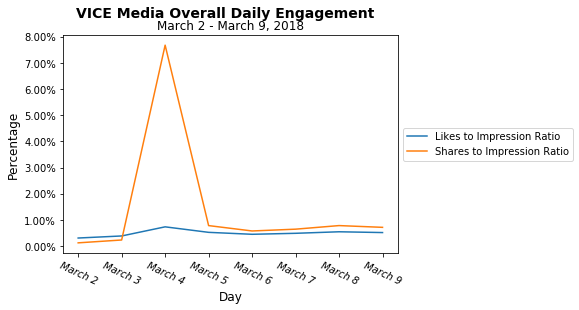

```python
#now let's visualize them!
#plt.scatter(day, impressions)
p1 = plt.plot(day, likes_per_impression)
p2 = plt.plot(day, shares_per_impression)
ax = plt.subplot()
vals = ax.get_yticks()
ax.set_yticklabels(['{:,.2%}'.format(x/100) for x in vals])
ax.set_xticklabels(['0','March 2','March 3','March 4', 'March 5', 'March 6','March 7', 'March 8',\
                   'March 9'], style='italic')
plt.xticks(rotation=-25)
plt.xlabel("Day", fontsize = 12)
plt.ylabel("Percentage", fontsize = 12)
plt.legend((p1[0],p2[0]),('Likes to Impression Ratio', 'Shares to Impression Ratio'),\
           loc='center left', bbox_to_anchor=(1, 0.5))
plt.suptitle("VICE Media Overall Daily Engagement", fontsize = 14, fontweight='bold')
plt.title("March 2 - March 9, 2018")
plt.savefig("ex_3_engagement_metrics.png", bbox_inches = "tight")
plt.show()
```

**Please Note:** Here, we can really see how much a power-post can move our numbers. I would show this to the team as evidence that even one big story can make a huge impact. I would want to look deeper here, if time allows, but I think the rise of "Investigating Modern-Day Slavery in the South" had a large impact.

### 8. What caveats would you have to add to an analysis using this data, especially around data quality, consistency or completeness? What changes or improvements would you ask the Data Engineering team to make to the data? What are some transformations you'd have to define and implement in order to make this data usable to a junior analyst who was only skilled in SQL?

There are many caveats to be discussed; here a few I’d highlight:

##### Meeting with Data Engineering Team.

**Build Incremental Numbers into the ETL Pipeline.** We have to figure out how we want to handle the Facebook API’s output. We want to setup an ETL pipeline to first incrementalize this data (rather than looking at it cumulatively), and then get that incremental information into a relational database that analysts can work with.

**Choose the Data Wisely.** The JSON files have an immense amount of data, especially when you flatten them, but we don’t need all of it. We should decided what are the say, 10 things, we really need to track and get good at those. If we have enough financial resources and enough engineering horsepower, I’m OK with storing and saving all of it, but in practice you rarely have that luxury.

**Write Up Documentation.** We also need to setup documentation for what each column means, and what the distinct range of values are. For example, I had to do a number of ‘select distinct’s’ to see how many categories were in a certain column; we will want to have that documented.

**Set up a Weekly Call with Facebook API dev team.** We’ll want to make sure we have a contact in Facebook, which they should have for their larger content-providers. I was unsure how some cumulative data seemed to go down, and I am thinking that as VICE grows there will need to be more of a live feed approach to a data warehouse. But, for this question, I’d want to know why any cumulative numbers would go down…which in this case is likely because an article in a former JSON was not in a subsequent JSON, and then we’ll probably start to want to build a ‘history table’ that keeps track of everything for us.

**More Demographic Info.** There was a lot of wonderful data, and we’d definitely want to know about WHO is liking, reacting, viewing, and sharing the post. Of course, we would need to observe privacy rules. I am a lawyer and I can look into this further.

**Looker?** I have heard great things about Looker, and we may want to set that up, so everyone can get access to the data even if they don’t know how to code. For the data team to be real stakeholders, we must get buy in from the whole organization, and I think Looker is a great first step.

**Overall, really great stuff.** Lots of hard work here from the team. Overall, I’m really impressed by the shear mount of things that are tracked. We’ve got a lot of information on what kinds of posts resonate. And I actually followed a few of the Facebook Permalinks, and I was really impressed by the journalism quality. I like how VICE can sort of get the viewer right there in the event, and just roll the camera. It allows viewers to make their own conclusion.

```python
#we canjust use max fucntions here since it's all cumulative
vertical_impressions = pd.read_sql_query("""
SELECT
    from_name,
    max(post_impressions) as impressions
FROM vice
GROUP BY 1
ORDER BY 2 desc
""", conn)
```

```python
vertical_impressions
```

|  | from_name | impressions |
| --- | --- | --- |
| 0 | VICE | 13090657 |
| 1 | Broadly | 850288 |
| 2 | VICE Video | 283670 |
| 3 | MOTHERBOARD | 256232 |
| 4 | MOTHERBOARD Deutschland | 75694 |

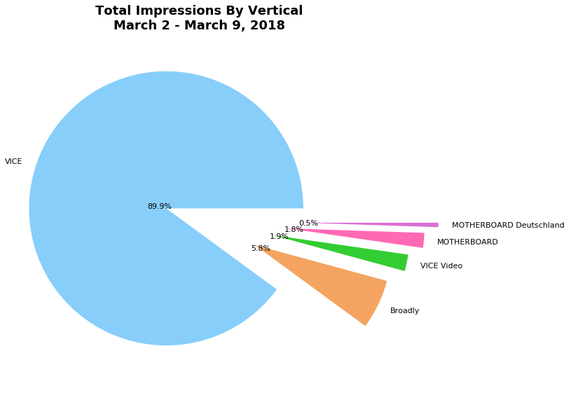

```python
#make pie chart
pie_labels = vertical_impressions.from_name
colors = ['lightskyblue','sandybrown','limegreen','hotpink','orchid']
piefig = plt.figure(figsize=(10,9))
pie_explode = (0.3, 0.4, 0.5, 0.6, 0.7)
plt.pie(vertical_impressions.impressions, labels=pie_labels, autopct='%1.1f%%',\
       explode=pie_explode, pctdistance=0.05, labeldistance=1.1, colors=colors,\
       textprops={'fontsize': 11})
plt.suptitle("Total Impressions By Vertical\nMarch 2 - March 9, 2018",\
             fontsize = 18, fontweight = 'bold')
plt.savefig("ex_4_total_impressions_by_vertical.png", bbox_inches = "tight")
plt.show()
```

## Thank you so much for your time and consideration.

## George John Jordan Thomas Aquinas Hayward, Optimist

[figure not shown]